# Core Quants Week 8 classwork

Sample solution - Lukas Wallrich

05/02/2021

# Exploring the ESS (European Social Survey) further

The [ESS](https://europeansocialsurvey.org/) is a huge survey run every two years across Europe, focusing on different social and political attitudes, as well as personal characteristics. Here we use Wave 7 from 2014, which collected 601 variables on 40,185 respondents and included a special module on the social determinants of health.

Today we will focus on replicating and extending some analyses from Thomson et al. (2017) who considered regional inequalities. At this stage, we will ignore two important aspects to focus on fundamental data manipulation skills: - we will *ignore survey weights*, which need to be used to make country results representative of the countries’ population, - we will *ignore different types of missing data.* I have recoded all missing values as NA; in a more thorough analysis, the different reasons for missingness reported in the codebook should be maintained.

# Loading the ESS data

I have selected a smaller set of 81 variables that we will look at over the next few weeks. I have saved the data as an RDS object - a R data type - and you can download it directly from the web by running the following code.

```r
library(tidyverse)

ess <- read_rds(url("http://empower-training.de/Gold/ess7_health.RDS"))
#The file is 20 MB large, so depending on your internet speed, it might take a minute.
#If that fails, your computer likely does not allow R to access the internet - then use the link to download the file and replace the URL by the local file path.
```

# Open the codebook or variable key

The ESS variable names are not intuitive and often it is not clear what the answer options are - the [Codebook](https://www.europeansocialsurvey.org/docs/round7/survey/ESS7_appendix_a7_e01_0.pdf) contains information on all that. I have also provided a variable key on learn.gold, which might be sufficient. Make sure to open either of them.

# Initial data preparation

- Filter to include only participants who are at least 18 years old
- Create a `bmi` variable: weight(in kg)/height(in m)^2 (^2 means squared, make sure to convert height to meters)
- Remove Israel (“IL”) as they do not provide information on subregions (and are not on the European map)
- Create a poor_health variable that is TRUE if someone’s health is 4 (bad) or 5 (very bad) and FALSE otherwise

```r
#Note that I am also adding a country_name variable - that makes plots easier to read than if we just use the codes includes in cntry

ess <- ess %>%
  filter(agea >= 18, cntry != "IL") %>%
  mutate(bmi = weight / (height / 100)^2, poor_health = health > 3,
         country_name = as_factor(cntry))
```

# Create a scale for depression

To test a scale for internal consistency, you need to calculate Cronbach’s alpha. To do that easily, you will need to install a package that has a specific function for it; we will use the `psych` package. So run install.packages(“psych”) in the console.

Note: Given that we will only use a single function from that package, I would recommend typing psych::alpha() rather than loading the full package, but you could as well run library(psych) and then use the alpha() function.

The proposed depression scale consists of the following items:

fltdpr flteeff slprl wrhpp fltlnl enjlf fltsd cldgng

```r
# Two items should be reverse coded because they do not measure high but low levels of depression. Have a look at the variable key pdf to identify which, and then create reverse-coded versions by subtracting them from 1 + the maximum. var1 below needs to be replaced by one of the variable names, and then you need to create the same command for the other

ess <- ess %>% mutate(enjlf_rev = 5 - enjlf, wrhpp_rev = 5 - wrhpp)

#Test whether the 8 items listed above can form an internally consistent scale
#Here, I am extracting the relevant field from the psych::alpha() output. That saves me from printing lots of irrelevant output. To figure out what to extract, use the str() function on the output - but that part is not essential
ess %>% select(fltdpr, flteeff, slprl, wrhpp_rev, fltlnl, enjlf_rev, fltsd, cldgng) %>% psych::alpha() %>% magrittr::extract2("total") %>% magrittr::extract("raw_alpha")
```

```
##  raw_alpha
##  0.8281315
```

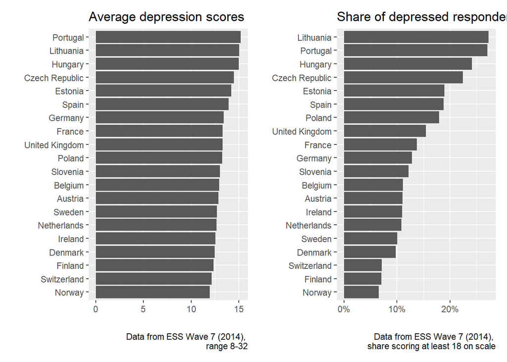

```r
#Create a new depression variable that is the sum of the eight. Ensure that you include the reverse-coded ones. Avoid using the sum() function inside mutate() - just add them up.
#Here I am using this rather complicated code to be able to include cases where some depression questions haven't been answered (na.rm = TRUE). You can also use the + sign, but it will give you a slightly smaller sample.

ess <- ess %>% mutate(depression_score = rowSums(select(., fltdpr,  flteeff,  slprl , wrhpp_rev , fltlnl , enjlf_rev , fltsd , cldgng), na.rm = TRUE))

#Calculate and plot the average depression score by country
#Remember that you can use group_by() before summarise() to create summaries per group
#A column chart `geom_col()` might be best; you can add `+ coord_flip()` to get horizontal bars with better-to-read labels
#If you want to arrange the bars, use the reorder function on the x-axis, e.g., ggplot(aes(x=reorder(cntry, depression_score), y=depression_score))

#Note that I do not print but save the plot - then I can show them side-by-side in a moment.

plot_continuous <- ess %>%
  group_by(country_name) %>%
  summarise(depression_score = mean(depression_score, na.rm = TRUE)) %>%
  ggplot(aes(x = reorder(country_name, depression_score), y = depression_score)) +
  geom_col() +
  coord_flip() + labs(title = "Average depression scores", x="", y="", caption = "Data from ESS Wave 7 (2014), \n range 8-32")
#In the article, they turned the depression score into a categorical variable - just depressed vs. not depressed, based on whether the score was higher than 10 (in our data, that is 18 - they started from 0 rather than one. Create a `depressed` variable that indicates whether someone is depressed (i.e. scored 18 or more), and create another column chart that shows the proportion depressed. Is the order different? Which measure is more interesting to you?

ess <- ess %>% mutate(depressed = depression_score >= 18)

plot_binary <- ess %>%
  group_by(country_name) %>%
  summarise(share_depressed = mean(depressed, na.rm = TRUE)) %>%
  ggplot(aes(x = reorder(country_name, share_depressed), y = share_depressed)) +
  geom_col() +
  coord_flip() +
  scale_y_continuous(labels = scales::percent_format()) +
  labs(title = "Share of depressed respondents", x="", y="", caption = "Data from ESS Wave 7 (2014), \n share scoring at least 18 on scale")
#To show the plots side-by-side, we need the patchwork package. The code below installs it if necessary, and then loads it (you should usually not include install.packages() in a code file, but this works fine because it first checks whether the package is available.)

if (!require("pacman")) install.packages("pacman")
pacman::p_load(patchwork)

plot_continuous + plot_binary #Show side-by_side
```

In the following, we could follow the guidance of the paper and filter out regions with less than 100 respondents - which results in a fairly large share of regions with missing data. So for now, let’s switch to a **cut-off of 50 responses per region**. If we wanted to publish this, we would need to do some further analyses on robustness to find the best balance between stable results and broad geographic coverage.

# Map health and depression per region

In the paper, they used deciles to rank regions. We will use relative odds for being in poor health or depressed. But let’s first consider how to draw maps.

## Prepare for drawing maps

To be able to draw maps with correct projection, you need two additional packages as well as the required data with borders. If you run this chunk, you will install those packages and download the geodata - already prepared with the NUTS 1 and 2 regions as they are used in the article, and with the names aligned so that they match the ESS data.

```r
if (!require("pacman")) install.packages("pacman")
pacman::p_load(maps, mapproj)

geo_data <- read_rds(url("http://empower-training.de/Gold/geodata_for_ess7.RDS"))

#We will merge the geodata to the ESS by region and country. For that, it helps to align variable names - the following line does this

geo_data <- geo_data %>% rename(cntry = CNTR_CODE, health_region = NUTS_NAME)
```

## Drawing maps

For ggplot, maps are polygons that consist of individual lines - drawn with `geom_polygon()`. To account for the fact that degrees of longitude and latitude cover very different distances, especially up north, we need to use a map projection, offered by `coord_map()`. We also need to zoom in on the European mainland, ignoring overseas territories and the like. For `coord_map()` we need to choose a good map projection - you can have a look [here](https://observablehq.com/@toja/five-map-projections-for-europe) to see some of them in action. The European Environmental Agency suggests to use an azimuthal equal-area projection for statistical analysis as it more adequately represents the size of places, so let’s go for that here.

Typically, only `fill` is used to convey information on maps. So you can copy-paste the code below and replace fill and labels to create meaningful maps.

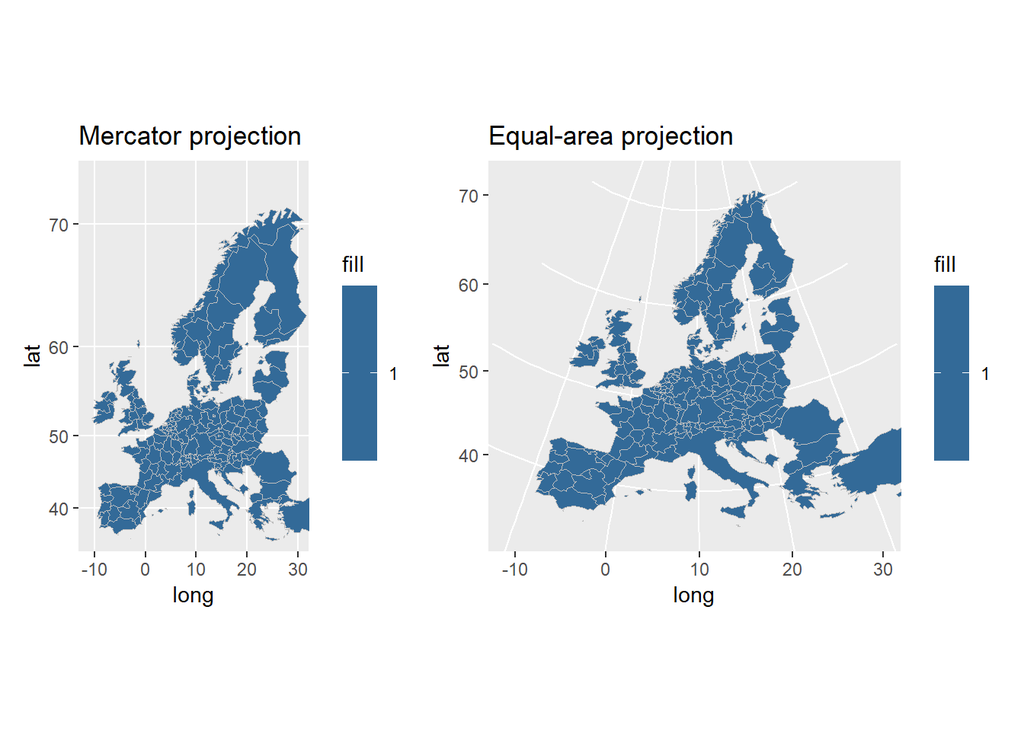

```r
map_mercator <- geo_data %>%
  ggplot(aes(x = long, y = lat, group = group, fill = 1)) +
  geom_polygon(color = "grey", size = .25) +
  coord_map(xlim = c(-11, 30), ylim = c(35, 72), projection = "mercator") + labs(title = "Mercator projection")

map_equal_area <- geo_data %>%
  ggplot(aes(x = long, y = lat, group = group, fill = 1)) +
  geom_polygon(color = "grey", size = .25) +
  coord_map(xlim = c(-11, 30), ylim = c(35, 72), projection = "azequalarea") + labs(title = "Equal-area projection")

map_mercator + map_equal_area
```

# Calculate relative risk

Calculate the average share of people who are depressed or in poor health across the dataset. Then calculate the share per region `health_region` and divide that by the overall share to get a relative risk. Finally, plot two maps with regions filled by these relative risks.

**Please note that I am adding quite a lot of formatting to the maps here - not all of that is essential, but I wanted to show you how to get close to a publishable product.** If you do not understand what some element of the ggplot-code is doing, a good way to find out is to delete it and see what changes.

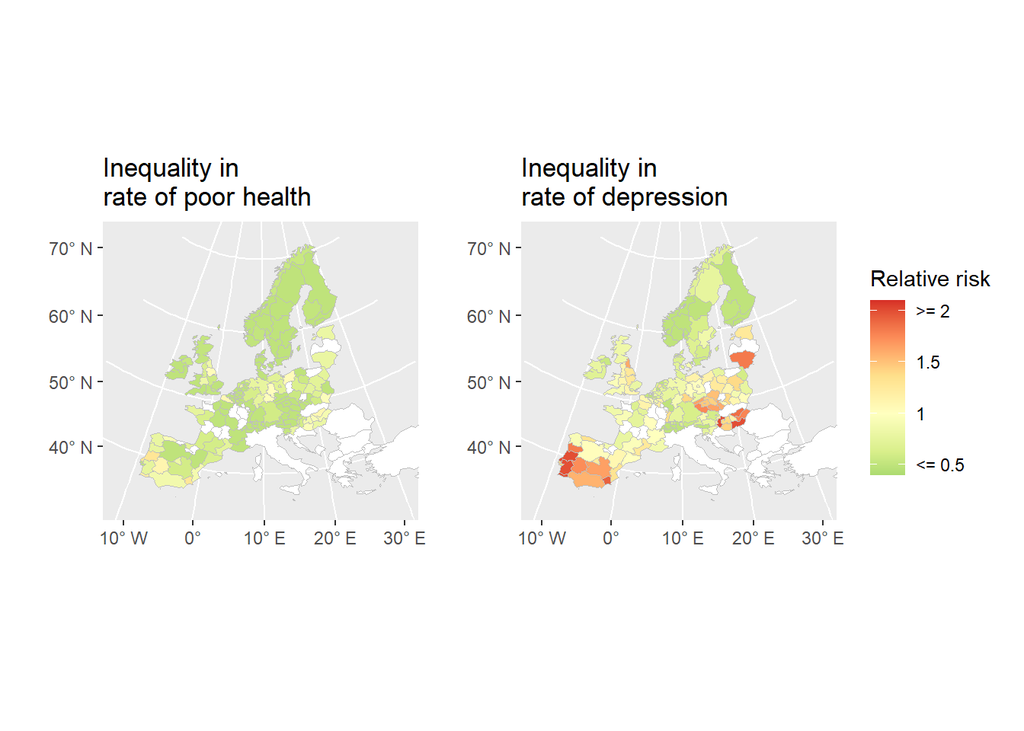

```r
#Here we should really use weights once - pweight adjusts for unequal population sizes between countries. Without that, Europe-wide averages make very little sense.
total_depressed <- weighted.mean(ess$depressed, ess$pweight, na.rm = TRUE)
total_poor_health <- weighted.mean(ess$poor_health, ess$pweight, na.rm = TRUE)

# create correct labels for the axes
geo_labels <- tibble(
  eastwest_breaks = seq(-10, 30, 10),
  northsouth_breaks = c(seq(40, 70, 10), NA)
)

geo_labels <- geo_labels %>% mutate(
  eastwest_labels = case_when(
    eastwest_breaks < 0 ~ paste0(abs(eastwest_breaks), "° W"),
    eastwest_breaks > 0 ~ paste0(eastwest_breaks, "° E"),
    TRUE ~ paste0(eastwest_breaks, "°")
  ),
  northsouth_labels = paste0(northsouth_breaks, "° N")
)

# Set limits on risk range (otherwise, extremes will dominate colours)
risk_range <- c(0.5, 2)

risk_labels <- tibble(
  breaks = seq(risk_range[1], risk_range[2], 0.5),
  labels = breaks
)

# Label extremes as smaller/greater than
risk_labels$labels[1] <- paste("<=", risk_labels$labels[1])
risk_labels$labels[length(risk_labels$labels)] <- paste(">=", risk_labels$labels[length(risk_labels$labels)])

#Helper function to allow 1 (i.e. being on the European average) to be the midpoint of the fill scale
mid_rescaler <- function(mid = 1) {
  function(x, to = c(0, 1), from = range(x, na.rm = TRUE)) {
    scales::rescale_mid(x, to, from, mid)
  }
}


map_depressed <- ess %>%
  #Calculate relative risk per region
  group_by(health_region) %>%
  summarise(odds_depressed = mean(depressed, na.rm = TRUE) / total_depressed, N = n()) %>%
  #Limit it to established risk range
  mutate(odds_depressed = ifelse(odds_depressed > risk_range[1], odds_depressed, risk_range[1]), odds_depressed = ifelse(odds_depressed < risk_range[2], odds_depressed, risk_range[2])) %>%
  #Filter for regions with minimum number of observations
  filter(N >= 50) %>%
  #Join to geo_data (coordinates)
  right_join(geo_data) %>%
  ggplot(aes(x = long, y = lat, group = group, fill = odds_depressed)) +
  geom_polygon(color = "grey", size = .25) +
  #Define map-projection
  coord_map(xlim = c(-11, 30), ylim = c(35, 72), projection = "azequalarea") +
  #Define fill colours and scale labels
scale_fill_distiller(palette = "RdYlGn", na.value = "white", limits = c(risk_range[1] - 0.1, risk_range[2] + 0.1), breaks = risk_labels$breaks, labels = risk_labels$labels, rescaler = mid_rescaler()) +
  #Define labels for x- and y-axes
  scale_x_continuous(breaks = geo_labels$eastwest_breaks, labels = geo_labels$eastwest_labels) +
  scale_y_continuous(breaks = geo_labels$northsouth_breaks, labels = geo_labels$northsouth_labels) +
#Note that \n adds a line break into the title
    labs(x = "", y = "", fill = "Relative risk", title = "Inequality in \nrate of depression")
map_health <- ess %>%
  group_by(health_region) %>%
  summarise(odds_poor_health = mean(poor_health, na.rm = TRUE) / total_depressed, N = n()) %>%
  mutate(odds_poor_health = ifelse(odds_poor_health > risk_range[1], odds_poor_health, risk_range[1]), odds_poor_health = ifelse(odds_poor_health < risk_range[2], odds_poor_health, risk_range[2])) %>%
  filter(N >= 50) %>%
  right_join(geo_data) %>%
  ggplot(aes(x = long, y = lat, group = group, fill = odds_poor_health)) +
  geom_polygon(color = "grey", size = .25) +
  coord_map(xlim = c(-11, 30), ylim = c(35, 72), projection = "azequalarea") +
  scale_fill_distiller(palette = "RdYlGn", na.value = "white", limits = c(risk_range[1] - 0.1, risk_range[2] + 0.1), breaks = risk_labels$breaks, labels = risk_labels$labels, rescaler = mid_rescaler()) +
  scale_x_continuous(breaks = geo_labels$eastwest_breaks, labels = geo_labels$eastwest_labels) +
  scale_y_continuous(breaks = geo_labels$northsouth_breaks, labels = geo_labels$northsouth_labels) +
  labs(x = "", y = "", fill = "Relative risk", title = "Inequality in \nrate of poor health")
map_health + map_depressed + plot_layout(guides = "collect")
```

## Wrapping up

You should be able to make sense of this code, but don’t need to be able to produce all of it yourself. Please bring questions to class.